# 随机变量的生成

王宁宁

**目的** ： 生成某特定随机变量的随机数

# 简介

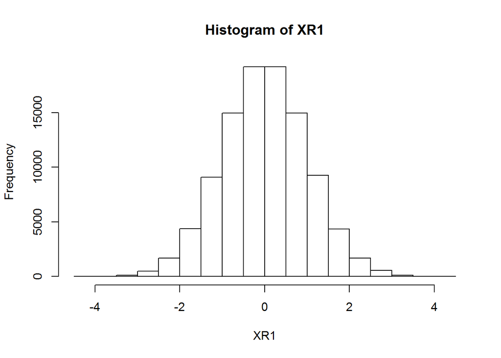

```r
XR1 <- rnorm(100000)
hist(XR1)
```

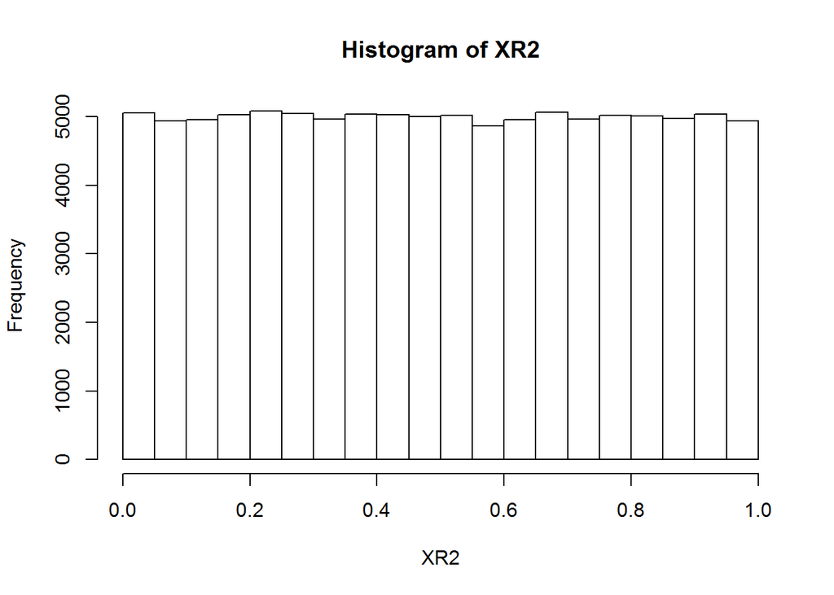

```r
XR2 <- runif(100000)
hist(XR2)
```

R 中生成随机数的函数：

- `rnorm`: generate random Normal variates with a given mean and standard deviation
- `dnorm`: evaluate the Normal probability density (with a given mean/SD) at a point (or vector of points)
- `pnorm`: evaluate the cumulative distribution function for a Normal distribution
- `rpois`: generate random Poisson variates with a given rate

Probability distribution functions usually have four functions associated with them. The functions are prefixed with a

- `d` for density
- `r` for random number generation
- `p` for cumulative distribution
- `q` for quantile function

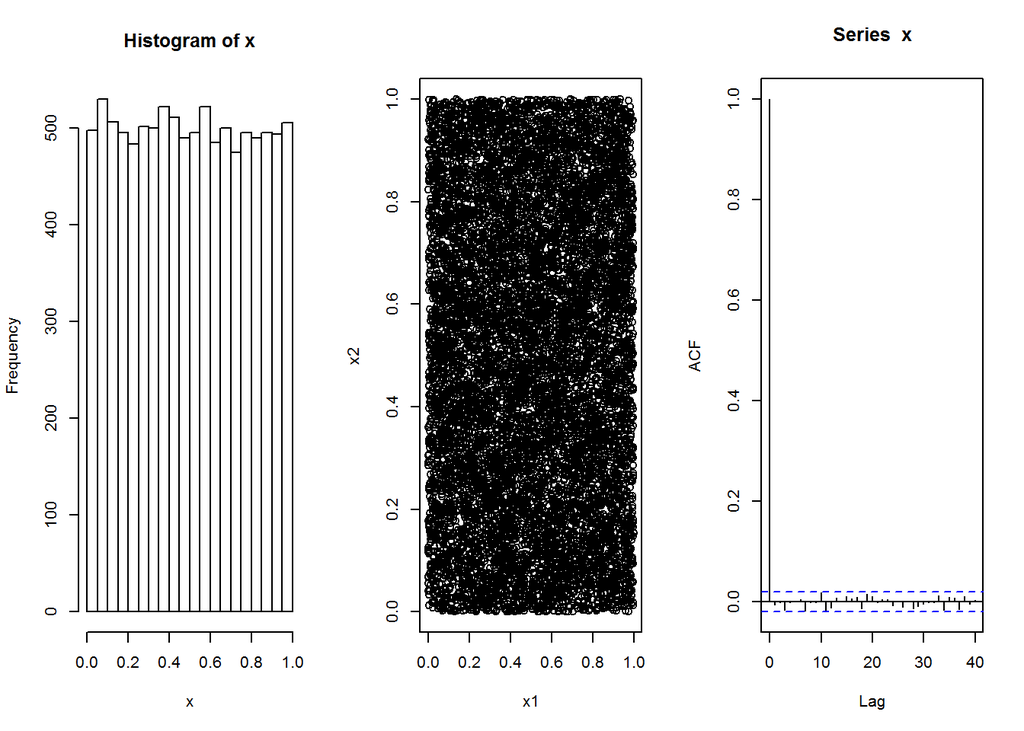

```r
 Nsim=10^4 #number of random numbers
 x=runif(Nsim)
 x1=x[-Nsim] #vectors to plot
 x2=x[-1] #adjacent pairs
 par(mfrow=c(1,3))
 hist(x)
 plot(x1,x2)
 acf(x)
```

随机数的生成都依赖均匀分布的随机数，但均匀分布的随机数所有的算法都是生成伪随机数，只要生产函数的种子确定了，随机数的序列就确定了。

```r
set.seed(1)
runif(5)
```

```
## [1] 0.2655087 0.3721239 0.5728534 0.9082078 0.2016819
```

```r
set.seed(1)
runif(5)
```

```
## [1] 0.2655087 0.3721239 0.5728534 0.9082078 0.2016819
```

```r
set.seed(2)
runif(5)
```

```
## [1] 0.1848823 0.7023740 0.5733263 0.1680519 0.9438393
```

# 反函数法

下面假定 $F(x)$ 严格单调：

## **原理**

随机变量 $X\sim F(x)$， 则 $F(X)$ 服从均匀分布 $U(0,1)$，也就是: $F^{-1}(U)\sim F(x)$。

证明： 设$X\sim F^{-1}(U)$，其分布函数为：
$$\begin{align*}
F_X (x)&=P\{X\le x\}\\
&=P\{F^{-1}(U)\le x\}\\
&=P\{F(F^{-1}(U)) \le F(x)\}\\
&=P\{U\le F(x) \}\\
&=F(x)
\end{align*}$$

## **例1**

假定 $X\sim Exp(1)$， $F(x)=1-e^{-x}$，反函数为$x=-log(1-u)$， 所以： 假定 $U\sim U(0,1)$ 则：$X=-logU\sim Exp(1)$

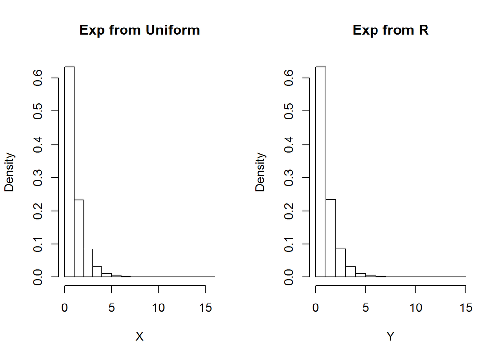

```r
set.seed(30)
Nsim=10^6
U=runif(Nsim)
X=-log(U) #transforms of uniforms
Y=rexp(Nsim) #exponentials from R
par(mfrow=c(1,2)) #plots
hist(X,freq=F,breaks=18,main="Exp from Uniform")
hist(Y,freq=F,breaks=18,main="Exp from R")
```

## **练习**：

假定 $X_i\sim Exp(1)$ 且相互独立，求下列分布：
$$\begin{align*}
Y=&\sum_{j=1}^n X_j\\
Y=&b\sum_{j=1}^a X_j\\
Y=&\frac{\sum_{j=1}^a X_j}{\sum_{j=1}^{a+b} X_j}\\
\end{align*}$$

# 正态分布的生成

Box-Muller 算法：

假定： $U_1,U_2\sim U(0,1)$ 且相互独立， 则：

$$\begin{align*}
X_1&=\sqrt{-2log(U_1)} cos (2\pi U_2)\\
X_2&=\sqrt{-2log(U_1)} sin (2\pi U_2)
\end{align*}$$
相互独立且 $\sim N(0,1)$ 。

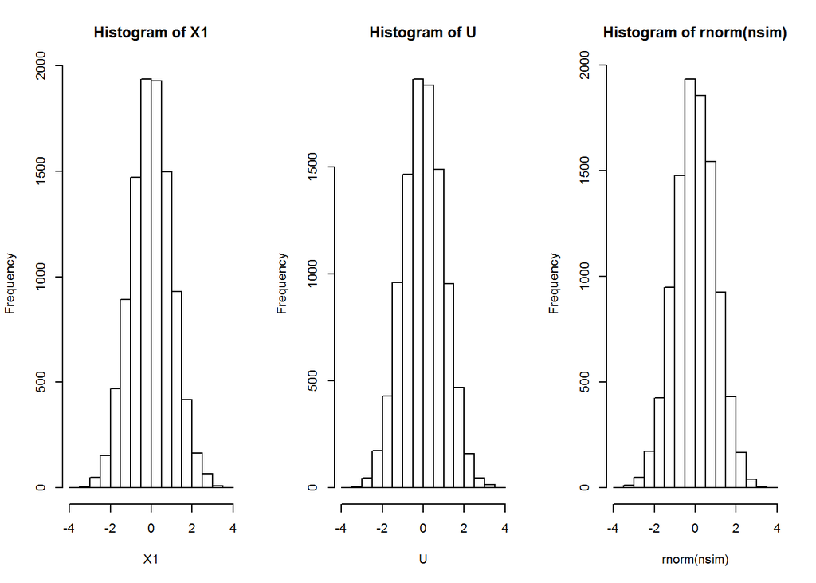

# 筛法

假设我们已经有了一种生成密度函数为$g(x)$ 的随机变量的方法，现在利用这种方法生成密度函数为 $f(x)$ 的随机变量。

## **筛法原理**

我们先生成来自 $g(x)$ 的随机变量 $Y$， 然后以正比于 $F(Y)\over g(Y)$ 的概率接收此值。

设：
$$\frac{{f(y)}}{{g(y)}} \le M,\quad \forall y$$

证明：

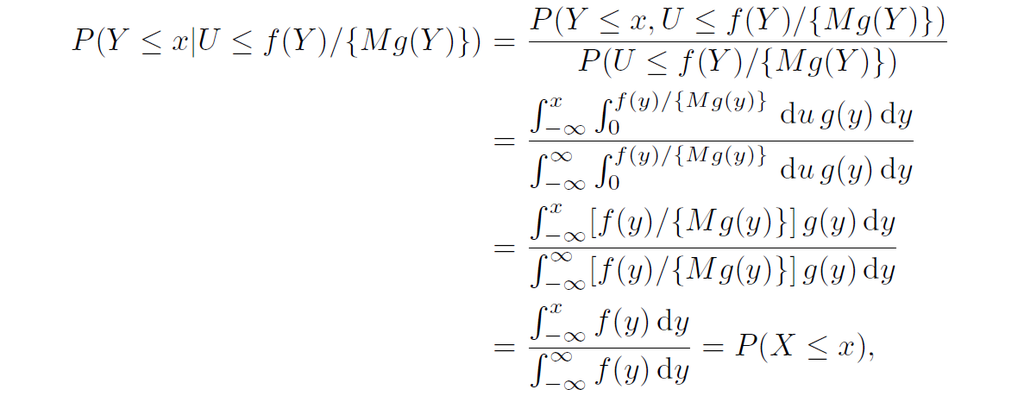

## 例2：

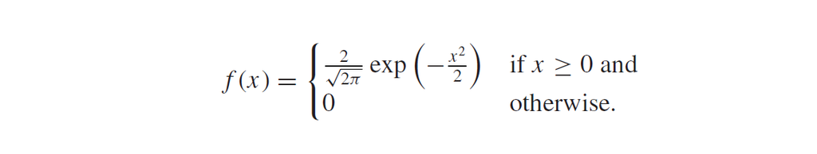

已知，参数为 $\lambda$ 的指数分布的密度为：

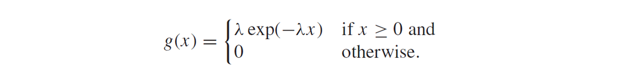

可得：

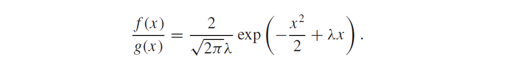

对于所有的 $x\ge 0$ :

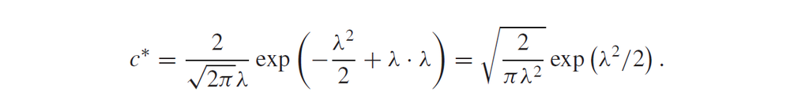

上述函数在 $\lambda=1$ 时取最小值： 此时：
$$M= \sqrt{2\over{\pi }}exp({1\over 2})$$

设计R 程序实现上述过程：

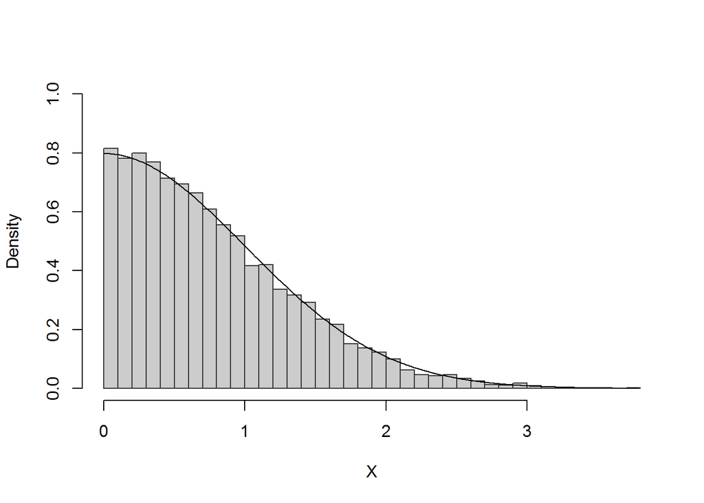

```r
set.seed(20)

f <- function(x) {
  return((x>0) * 2 * dnorm(x,0,1))
}
g <- function(x) { return(dexp(x,1)) }
c <- sqrt(2 * exp(1) / pi)

rhalfnormal <- function(n) {
  res <- numeric(length=n)
  i <- 0
  while (i<n) {
    U <- runif(1, 0, 1)
    X <- rexp(1, 1)
    if (c * g(X) * U <= f(X)) {
      i <- i+1
      res[i] <- X;
    }
  }
  return(res)
}

X <- rhalfnormal(10000)
hist(X, breaks=50, prob=TRUE, ylim=c(0,1),
     main=NULL, col="gray80", border="gray20")
curve(f, min(X), max(X), n=500,
      ylim=c(0,1), ylab="f", add=TRUE)
```

# 混合分布

$$X = \left\{ \begin{array}{ll}
X_1 & \alpha\\
X_2 & 1-\alpha
\end{array} \right.$$

某个随机变量以 $\alpha$ 的概率来自随机变量 $X_1$，而以 $1-\alpha$ 的概率来自随机变量 $X_2$

算法：

1. 产生随机变量$X_1$
2. 产生随机变量$X_2$
3. 产生均匀分布随机数 $U$: 如果 $U\le \alpha$，则令 $X=X_1$， 否则 令 $X=X_2$.

# 课堂作业

使用`system.time`比较生成正态随机数的效率：

- 中心极限定理
- Box-Muller方法
- 使用`rnorm`生成

```r
system.time(rnorm(1000000))
```

```
##    user  system elapsed
##    0.07    0.00    0.08
```

结果：

中心极限定理：

```r
system.time(f1(nsim))
```

```
##    user  system elapsed
##    3.79    0.00    3.79
```

Box-Mulur:

```r
system.time(f2(nsim))
```

```
##    user  system elapsed
##    0.17    0.00    0.17
```

rnorm:

```r
system.time(rnorm(nsim))
```

```
##    user  system elapsed
##    0.07    0.01    0.08
```

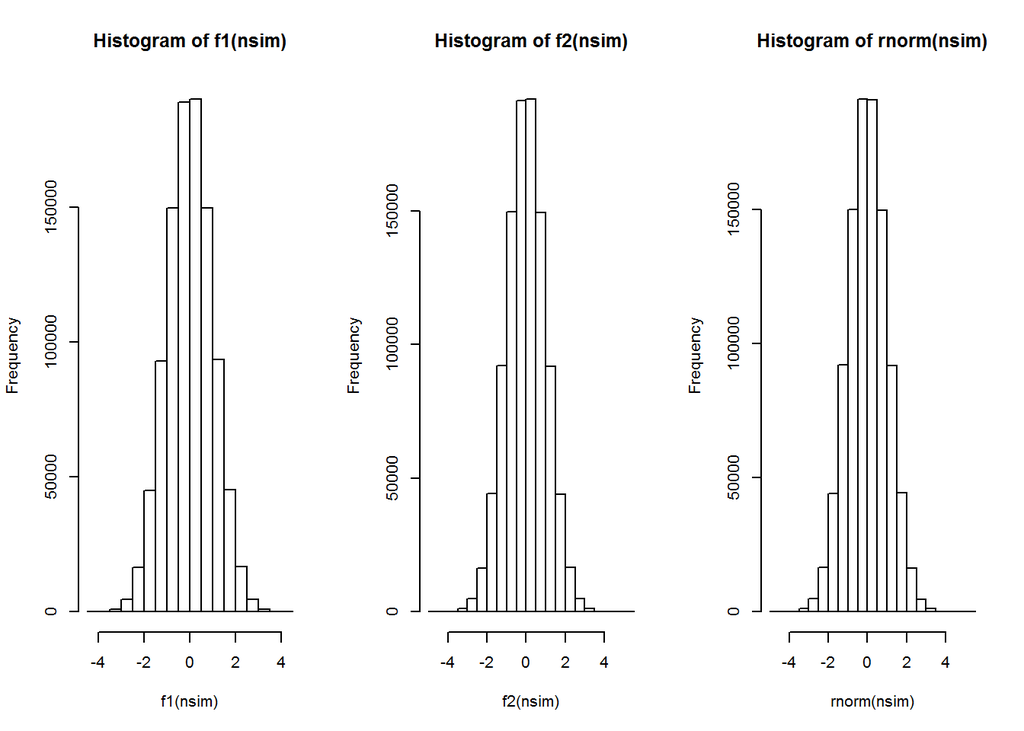

```r
par(mfrow=c(1,3))
hist(f1(nsim))
hist(f2(nsim))
hist(rnorm(nsim))
```

返回[课程主页](https://statstudy.github.io/Rmulti.html)。